# Abstract

Real world data loaded and visualized below:

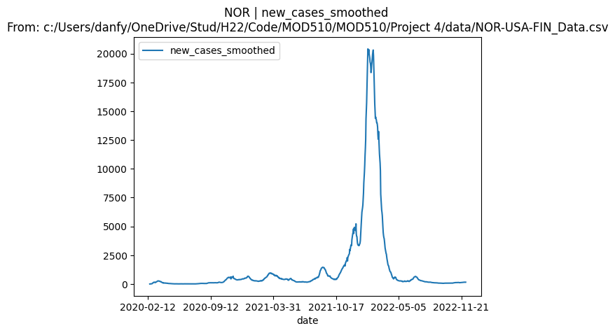

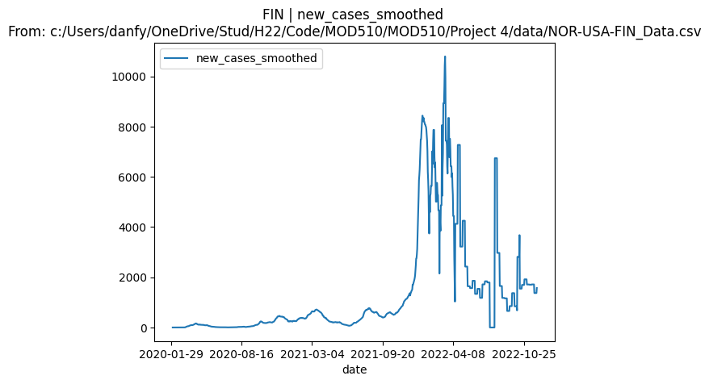

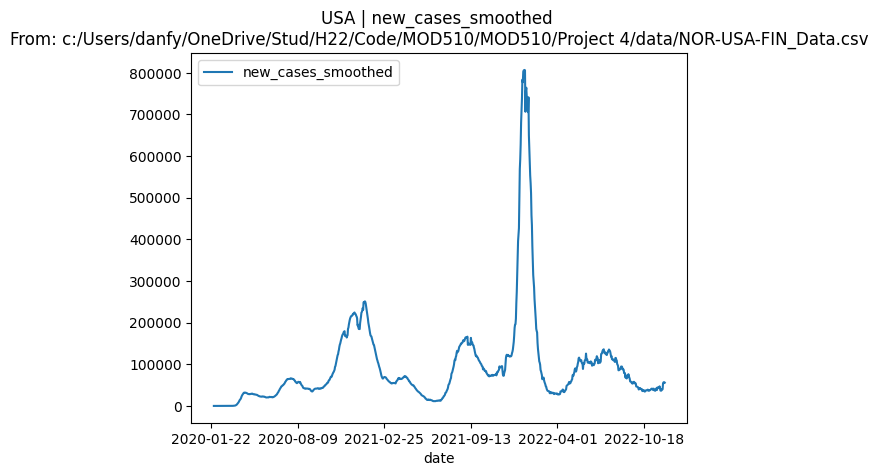

```python
cwd = os.getcwd()
cwd = cwd.replace("\\", "/")

path = f"{cwd}/data/NOR-USA-FIN_Data.csv"

df = pd.read_csv(path)
useful_data_df = df.drop(
    df.columns.difference(['iso_code',
                           'date',
                           'new_cases_smoothed',
                           'new_deaths_smoothed',
                           'new_vaccinations_smoothed',
                           'population'
                           ]), 1)
NOR_useful_data_df = useful_data_df[useful_data_df['iso_code'] == "NOR"]
FIN_useful_data_df = useful_data_df[useful_data_df['iso_code'] == "FIN"]
USA_useful_data_df = useful_data_df[useful_data_df['iso_code'] == "USA"]
#   "new_cases_smoothed"
# | "new_deaths_smoothed"
# | "new_vaccinations_smoothed"
y = "new_cases_smoothed"
NOR_useful_data_df.plot(x="date", y=y)
plt.title(f"NOR | {y} \nFrom: {path}")
FIN_useful_data_df.plot(x="date", y=y)
plt.title(f"FIN | {y} \nFrom: {path}")
USA_useful_data_df.plot(x="date", y=y)
plt.title(f"USA | {y} \nFrom: {path}")
```

As seen above, the data of new cases, even when smoothed, is quite erratic. We can not hope to be able to match this, but instead will try to match to the peaks of both models, as they occur approximately over the same time/sample interval. The peak is then the total population of our model, so $100\%$ for the model is the found amount in the image above. This is to save computation, because we only have integer values of population and infected, and because the general idea and solving method is the same.

```
Current parameters:
size=10
time_steps=170
pop_size=1000
no_init_infected=1
iterations=2
seeds=[480, 720]
recovery_probability=0.0
infection_probability=0.005
```

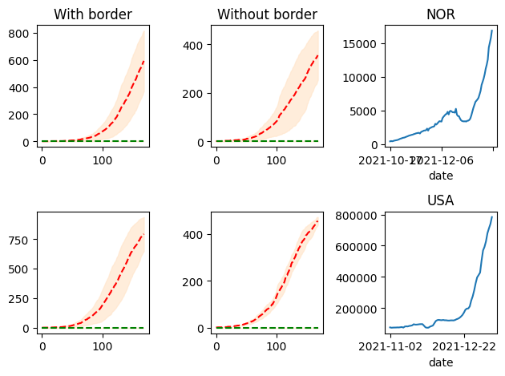

```python
# Trying to match results to some data
size=10
time_steps=170
pop_size=1000
no_init_infected=1
iterations=2
seeds=[480, 720]
recovery_probability=0.0
infection_probability=0.005
borders = []
noBorders = []
for seed in seeds:
    borders.append(RandomlyViral(
        iterations=iterations,
        no_init_infected=no_init_infected,
        population_size=pop_size,
        nx=size,
        ny=size,
        time_steps=time_steps,
        recovery_probability=recovery_probability,
        infection_probability=infection_probability,
        Recovery="on",
        random_seed=seed))
    noBorders.append(RandomlyViral(
        iterations=iterations,
        no_init_infected=no_init_infected,
        population_size=pop_size,
        nx=size,
        ny=size,
        time_steps=time_steps,
        recovery_probability=recovery_probability,
        infection_probability=infection_probability,
        Recovery="on",
        no_border=True,
        random_seed=seed))

print(f"Current parameters:\nsize={size}\ntime_steps={time_steps}")
print(f"pop_size={pop_size}\nno_init_infected={no_init_infected}")
print(f"iterations={iterations}\nseeds={seeds}")
print(
    f"recovery_probability={recovery_probability}\ninfection_probability={infection_probability}")

fig, axs = plt.subplots(len(seeds), 3)
for i, (border, noBorder) in enumerate(zip(borders, noBorders)):
    border.plot_simulation(ax=axs[i, 0], plot_susc=False)
    noBorder.plot_simulation(ax=axs[i, 1], plot_susc=False)

axs[0, 0].set_title('With border')
axs[0, 1].set_title('Without border')

NOR_useful_data_df[600:700].plot(x="date", y=y,
                                 ax=axs[0, 2],
                                 legend=False)
USA_useful_data_df[650:720].plot(x="date", y=y,
                                 ax=axs[1, 2],
                                 legend=False)
axs[0, 2].set_title('NOR')
axs[1, 2].set_title('USA')

fig.tight_layout()
```

Above is a approximate fit for the Norwegian case.

```
Current parameters:
size=15
time_steps=50
pop_size=25000
no_init_infected=1
iterations=2
seeds=[480, 720]
recovery_probability=0.0
infection_probability=0.001
```

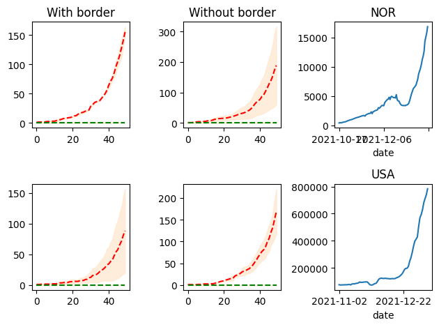

```python
# Trying to match results to some data
size=15
time_steps=50
pop_size=int((100000/(30**2))*(size**2))
no_init_infected=1
iterations=2
seeds=[480, 720]
recovery_probability=0.0
infection_probability=0.001
borders = []
noBorders = []
for seed in seeds:
    borders.append(RandomlyViral(
        iterations=iterations,
        no_init_infected=no_init_infected,
        population_size=pop_size,
        nx=size,
        ny=size,
        time_steps=time_steps,
        recovery_probability=recovery_probability,
        infection_probability=infection_probability,
        Recovery="on",
        random_seed=seed))
    noBorders.append(RandomlyViral(
        iterations=iterations,
        no_init_infected=no_init_infected,
        population_size=pop_size,
        nx=size,
        ny=size,
        time_steps=time_steps,
        recovery_probability=recovery_probability,
        infection_probability=infection_probability,
        Recovery="on",
        no_border=True,
        random_seed=seed))

print(f"Current parameters:\nsize={size}\ntime_steps={time_steps}")
print(f"pop_size={pop_size}\nno_init_infected={no_init_infected}")
print(f"iterations={iterations}\nseeds={seeds}")
print(
    f"recovery_probability={recovery_probability}\ninfection_probability={infection_probability}")

fig, axs = plt.subplots(len(seeds), 3)
for i, (border, noBorder) in enumerate(zip(borders, noBorders)):
    border.plot_simulation(ax=axs[i, 0], plot_susc=False)
    noBorder.plot_simulation(ax=axs[i, 1], plot_susc=False)

axs[0, 0].set_title('With border')
axs[0, 1].set_title('Without border')

NOR_useful_data_df[600:700].plot(x="date", y=y,
                                 ax=axs[0, 2],
                                 legend=False)
USA_useful_data_df[650:720].plot(x="date", y=y,
                                 ax=axs[1, 2],
                                 legend=False)
axs[0, 2].set_title('NOR')
axs[1, 2].set_title('USA')

fig.tight_layout()
```

[figure not shown]

Above is a approximate fit for the United states case. The inserted image is with more computationally heavy parameters, but better fit.

### Summary of exercise 3

The chosen new features added small changes to the simulations, which was quite underwhelming. Nonetheless the features in themselves are not pointless, and specifically contribute to highlighting the difference in variability.

As before specifically for the border and borderless comparison: From these results the basic and more or less only possible conclusion is:

**The variability in a borderless simulation is greater, but the difference in mean value is negligable**.

Practically it means that the results give us the following guidance:

**With large enough simulations, it should behave practically the same way, with or without borders, but to be computationally efficient, the simulation with border should be used since it is more stable around the "common" mean.**

The comparison between waves and before is a bit less clear:

There is not too much to say about it, since it is a very basic improvement, but we suspect it would scale in complexity along with any features added later like;

1. Recovered people having a lower, but not $0\%$ chance of becoming infected.
2. Infectious people having area of effect spreading instead of only in-place.
3. Infectious people having variable degrees of infection, meaning;
   1. Different infection probability to those around them.
   2. Different movement pattern, for example every other time step
4. Recovery areas (Hospitals);
   1. Where the infected walk towards.
   2. Odds of spreading when inside is lower.
   3. Recovery rate only exist here.

And of course there are infinitely more, but imagining they are in the solution and then introducing these waves would then be a massively impactful effect, in contrast to how it is now. And so the effect should not be underappreciated. This is noted because we made the conscious decision of choosing 2 new features, and to match to real world data.

When it came to the mapping to the real world data there was several issues which mainly related to computation time that limited our ability to do a proper match. As the model is right now, and also given several more features like death or not letting infected people move, the ability to match it to real data would still be basically as useful as just creating a exponential function of the form:

$$f(t) = -(1 - a\cdot e^{t})$$

Tweaking the parameters even with rescaled numbers of people and time rate, the probabilities will be using fundamentally wrong assumptions and end up being basically just forced onto the real world data.

This is shown below:

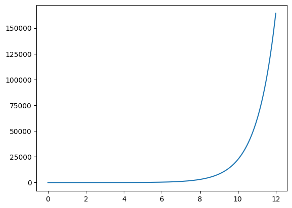

```python
a = 1.01 # 1%
x = lambda t : -(1 - a*math.e**t )

t = np.arange(0,12, 0.001)

plt.plot(t, x(t))
```

Or else it would simply be a fake comparison, where we would have a wave of infected people, but by the end everyone is just recovered. This would be completely wrong even though it might look right, as everyone isn't immune directly after in the real world (even if the effects and chance of getting infected is lowered).

Since the results felt somewhat underwhelming, we decided to add some more feature even though we already had implemented two... cause why not.

We decided to simply add deaths, since that is a natural addition. This is shown below:

```
Current parameters:
size=12
time_steps=40
pop_size=3000
no_init_infected=3
iterations=25
seeds=[480, 720]
recovery_probability=1e-07
infection_probability=0.8
death_rate=0.05
```

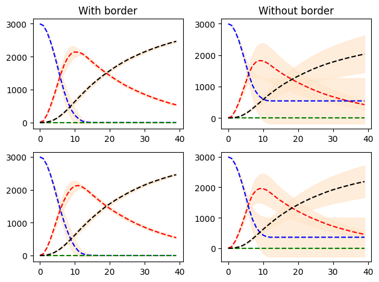

```python
size = 12
pop_size = 3000  # size*3
# math.ceil(size*(300*(size/10)))  # size = time_steps/(3*200)
time_steps = 40
no_init_infected = 3  # math.ceil(pop_size/100)
iterations = 25  # math.ceil(time_steps/pop_size)
seeds = [480, 720]  # np.arange(10*n, 10*(n+1))
recovery_probability = 0.00001e-2
infection_probability = 80e-2
death_rate = 5e-2

borders = []
noBorders = []
for seed in seeds:
    borders.append(RandomlyViral(
        iterations=iterations,
        no_init_infected=no_init_infected,
        population_size=pop_size,
        nx=size,
        ny=size,
        time_steps=time_steps,
        recovery_probability=recovery_probability,
        infection_probability=infection_probability,
        Recovery="on",
        random_seed=seed,
        death_rate=death_rate))
    noBorders.append(RandomlyViral(
        iterations=iterations,
        no_init_infected=no_init_infected,
        population_size=pop_size,
        nx=size,
        ny=size,
        time_steps=time_steps,
        recovery_probability=recovery_probability,
        infection_probability=infection_probability,
        Recovery="on",
        no_border=True,
        random_seed=seed,
        death_rate=death_rate))

print(f"Current parameters:\nsize={size}\ntime_steps={time_steps}")
print(f"pop_size={pop_size}\nno_init_infected={no_init_infected}")
print(f"iterations={iterations}\nseeds={seeds}")
print(
    f"recovery_probability={recovery_probability}\ninfection_probability={infection_probability}")
print(
    f"death_rate={death_rate}")


numPlots = 2*len(seeds)
fig, axs = plt.subplots(int(numPlots/2), 2)
axs = axs.T.flatten()
for i, (border, noBorder) in enumerate(zip(borders, noBorders)):
    border.plot_simulation(ax=axs[i])
    noBorder.plot_simulation(ax=axs[int(numPlots/2) + i])

axs[0].set_title('With border')
axs[int(numPlots/2)].set_title('Without border')
fig.tight_layout()
```

Another addition which maybe was more interesting was a adaptive recovery rate, dependent on the amount of dead people in the population. Can call it a scared population effect or something. It uses the following equation to update the recovery rate:

$$r = r_i + \left[\frac{2d\lambda + i\lambda}{3N}\right]$$

Where;

1. $r$ is the recovery rate
2. $d$ is the amount of deaths in the population
3. $i$ is the amount of infected in the population
4. $r_i$ is the initial/natural recovery rate
5. $N$ is the total population number
6. $\lambda$ is the scare factor / tuning parameter

This is done below, and the parameters for the model is printed.

```
Current parameters:
size=12
time_steps=40
pop_size=3000
no_init_infected=3
iterations=25
seeds=[480, 720]
recovery_probability=1e-07
infection_probability=0.8
death_rate=0.05
adaptive_recovery_rate=0.9230766923076923
```

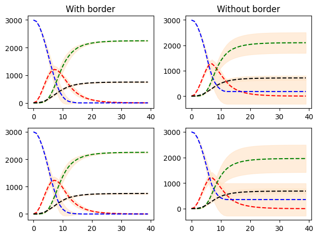

```python
size = 12
pop_size = 3000  # size*3
# math.ceil(size*(300*(size/10)))  # size = time_steps/(3*200)
time_steps = 40
no_init_infected = 3  # math.ceil(pop_size/100)
iterations = 25  # math.ceil(time_steps/pop_size)
seeds = [480, 720]  # np.arange(10*n, 10*(n+1))
recovery_probability = 0.00001e-2
infection_probability = 80e-2
death_rate = 5e-2

# recov = init + (2*death_perc*reac + infect_perc*reac)/3
desired_recov=0.4
infect_perc=0.5
death_perc=0.4

adaptive_recovery_rate = (desired_recov - recovery_probability)*3/(2*death_perc + infect_perc)
borders = []
noBorders = []
for seed in seeds:
    borders.append(RandomlyViral(
        iterations=iterations,
        no_init_infected=no_init_infected,
        population_size=pop_size,
        nx=size,
        ny=size,
        time_steps=time_steps,
        recovery_probability=recovery_probability,
        infection_probability=infection_probability,
        Recovery="on",
        random_seed=seed,
        death_rate=death_rate,
        adaptive_recovery_rate=adaptive_recovery_rate))
    noBorders.append(RandomlyViral(
        iterations=iterations,
        no_init_infected=no_init_infected,
        population_size=pop_size,
        nx=size,
        ny=size,
        time_steps=time_steps,
        recovery_probability=recovery_probability,
        infection_probability=infection_probability,
        Recovery="on",
        no_border=True,
        random_seed=seed,
        death_rate=death_rate,
        adaptive_recovery_rate=adaptive_recovery_rate))

print(f"Current parameters:\nsize={size}\ntime_steps={time_steps}")
print(f"pop_size={pop_size}\nno_init_infected={no_init_infected}")
print(f"iterations={iterations}\nseeds={seeds}")
print(
    f"recovery_probability={recovery_probability}\ninfection_probability={infection_probability}")
print(
    f"death_rate={death_rate}\nadaptive_recovery_rate={adaptive_recovery_rate}")


numPlots = 2*len(seeds)
fig, axs = plt.subplots(int(numPlots/2), 2)
axs = axs.T.flatten()
for i, (border, noBorder) in enumerate(zip(borders, noBorders)):
    border.plot_simulation(ax=axs[i])
    noBorder.plot_simulation(ax=axs[int(numPlots/2) + i])

axs[0].set_title('With border')
axs[int(numPlots/2)].set_title('Without border')
fig.tight_layout()
```

Observing the result above, and comparing it to previous ones, it is clear that the recovery is varying as expected. This is much more complex behaviour than anything previously.

Specifically by looking at the result just prior to this one, when deaths were just implemented, the difference can be seen very well. These two simulations used identical parameters, aside from the adaptability change to the recovery rate. In that previous one, everyone ended up dying. In this one most recovered.

Next, to test the effect of waves on this much more complex model:

Will just use identical parameters, and have the same 3 waves as previously in this assignment:

```
Current parameters:
size=12
time_steps=40
pop_size=3000
no_init_infected=3
iterations=25
seeds=[480, 720]
recovery_probability=1e-07
infection_probability=0.8
death_rate=0.05
adaptive_recovery_rate=0.9230766923076923
```

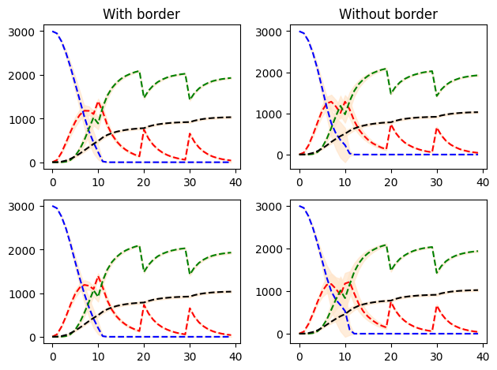

```python
size = 12
pop_size = 3000  # size*3
# math.ceil(size*(300*(size/10)))  # size = time_steps/(3*200)
time_steps = 40
no_init_infected = 3  # math.ceil(pop_size/100)
iterations = 25  # math.ceil(time_steps/pop_size)
seeds = [480, 720]  # np.arange(10*n, 10*(n+1))
recovery_probability = 0.00001e-2
infection_probability = 80e-2
death_rate = 5e-2

# recov = init + (2*death_perc*reac + infect_perc*reac)/3
desired_recov=0.4
infect_perc=0.5
death_perc=0.4

adaptive_recovery_rate = (desired_recov - recovery_probability)*3/(2*death_perc + infect_perc)
borders = []
noBorders = []
for seed in seeds:
    borders.append(RandomlyViral(
        iterations=iterations,
        no_init_infected=no_init_infected,
        population_size=pop_size,
        nx=size,
        ny=size,
        time_steps=time_steps,
        recovery_probability=recovery_probability,
        infection_probability=infection_probability,
        Recovery="on",
        random_seed=seed,
        death_rate=death_rate,
        adaptive_recovery_rate=adaptive_recovery_rate,
        wave_susc=0.1,
        wave_reco=0.3,
        num_waves=3,
        infectionWaves=True))
    noBorders.append(RandomlyViral(
        iterations=iterations,
        no_init_infected=no_init_infected,
        population_size=pop_size,
        nx=size,
        ny=size,
        time_steps=time_steps,
        recovery_probability=recovery_probability,
        infection_probability=infection_probability,
        Recovery="on",
        no_border=True,
        random_seed=seed,
        death_rate=death_rate,
        adaptive_recovery_rate=adaptive_recovery_rate,
        wave_susc=0.1,
        wave_reco=0.3,
        num_waves=3,
        infectionWaves=True))

print(f"Current parameters:\nsize={size}\ntime_steps={time_steps}")
print(f"pop_size={pop_size}\nno_init_infected={no_init_infected}")
print(f"iterations={iterations}\nseeds={seeds}")
print(
    f"recovery_probability={recovery_probability}\ninfection_probability={infection_probability}")
print(
    f"death_rate={death_rate}\nadaptive_recovery_rate={adaptive_recovery_rate}")


numPlots = 2*len(seeds)
fig, axs = plt.subplots(int(numPlots/2), 2)
axs = axs.T.flatten()
for i, (border, noBorder) in enumerate(zip(borders, noBorders)):
    border.plot_simulation(ax=axs[i])
    noBorder.plot_simulation(ax=axs[int(numPlots/2) + i])

axs[0].set_title('With border')
axs[int(numPlots/2)].set_title('Without border')
fig.tight_layout()
```

This result is somewhat as expected, and shows that the wave effect changes the final number of deaths.

Then with the same 10 as before:

```
Current parameters:
size=12
time_steps=40
pop_size=3000
no_init_infected=3
iterations=25
seeds=[480, 720]
recovery_probability=1e-07
infection_probability=0.8
death_rate=0.05
adaptive_recovery_rate=0.9230766923076923
```

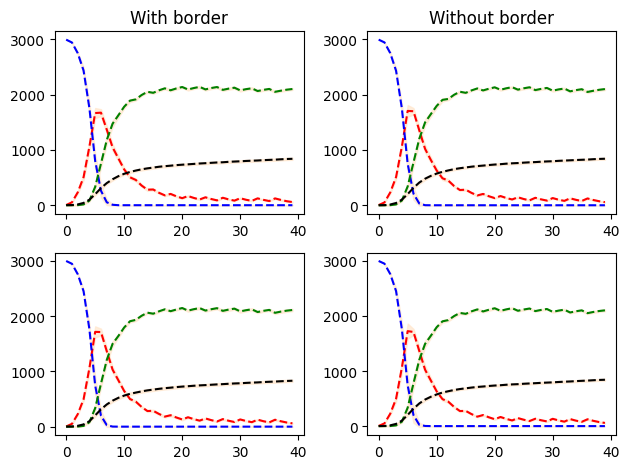

```python
size = 12
pop_size = 3000  # size*3
# math.ceil(size*(300*(size/10)))  # size = time_steps/(3*200)
time_steps = 40
no_init_infected = 3  # math.ceil(pop_size/100)
iterations = 25  # math.ceil(time_steps/pop_size)
seeds = [480, 720]  # np.arange(10*n, 10*(n+1))
recovery_probability = 0.00001e-2
infection_probability = 80e-2
death_rate = 5e-2

# recov = init + (2*death_perc*reac + infect_perc*reac)/3
desired_recov=0.4
infect_perc=0.5
death_perc=0.4

adaptive_recovery_rate = (desired_recov - recovery_probability)*3/(2*death_perc + infect_perc)
borders = []
noBorders = []
for seed in seeds:
    borders.append(RandomlyViral(
        iterations=iterations,
        no_init_infected=no_init_infected,
        population_size=pop_size,
        nx=size,
        ny=size,
        time_steps=time_steps,
        recovery_probability=recovery_probability,
        infection_probability=infection_probability,
        Recovery="on",
        random_seed=seed,
        death_rate=death_rate,
        adaptive_recovery_rate=adaptive_recovery_rate,
        wave_susc=0.01,
        wave_reco=0.03,
        num_waves=10,
        infectionWaves=True))
    noBorders.append(RandomlyViral(
        iterations=iterations,
        no_init_infected=no_init_infected,
        population_size=pop_size,
        nx=size,
        ny=size,
        time_steps=time_steps,
        recovery_probability=recovery_probability,
        infection_probability=infection_probability,
        Recovery="on",
        no_border=True,
        random_seed=seed,
        death_rate=death_rate,
        adaptive_recovery_rate=adaptive_recovery_rate,
        wave_susc=0.01,
        wave_reco=0.03,
        num_waves=10,
        infectionWaves=True))

print(f"Current parameters:\nsize={size}\ntime_steps={time_steps}")
print(f"pop_size={pop_size}\nno_init_infected={no_init_infected}")
print(f"iterations={iterations}\nseeds={seeds}")
print(
    f"recovery_probability={recovery_probability}\ninfection_probability={infection_probability}")
print(
    f"death_rate={death_rate}\nadaptive_recovery_rate={adaptive_recovery_rate}")


numPlots = 2*len(seeds)
fig, axs = plt.subplots(int(numPlots/2), 2)
axs = axs.T.flatten()
for i, (border, noBorder) in enumerate(zip(borders, noBorders)):
    border.plot_simulation(ax=axs[i])
    noBorder.plot_simulation(ax=axs[int(numPlots/2) + i])

axs[0].set_title('With border')
axs[int(numPlots/2)].set_title('Without border')
fig.tight_layout()
```

Here we can clearly observe that the smaller waves had much less of a effect.

## Conclusion

The main aim for this project was to model the spread of a disease through a population. The Monte Carlo principle was used for introducing randomness to the processes along the way. Movement of individuals, chance of infection, recovery, and even death - was all decided by the roll of the dice (or so to speak).

We observed that a deterministic ODE-model could be tuned to fit the Random Walk model quite well.

- Although it was not easy to grasp the exact meaning of the constant $\beta$, we observed the effectiveness of calibrating this constant.
- While calibrating $\tau$ we, unsurprisingly, found that if an infected individual has a 1% chance of recovering per time step, it will on average take 100 time steps for the individual to recover.

The strength of the Random walk approach is that its inherent modular framework relatively easy allows for adding-to, customizing and reworking the model. Through adding features and updating the model we had close to no issues with the stability of the code itself. It is clear that this approach is a rather blunt tool, which will not be used in situations where high orders of accuracy is needed. In situatuation like disease spreading, however, getting as close as a single order of magnitude may be close enough to guide decision making.

The limitations of the Random walk model became apparent while contemplating fitting it to real-world, big-scale data. The model shows the capability to model small sections of such datasets. We can imagine that we could gain insights to the effectiveness of regulations at different times or geographical locations by comparing how the curve-fitting constants would change between them. For the scope of this project we chose to not dive too deep into this rabbit hole.

All-in-all we have shown that chaotic behavior can be quite orderly when scaled up sufficiently. We must be careful not to misunderstand this, however, as the great Daniel Kahneman said: ' The idea that the future is unpredictable is undermined every day by the ease with which the past is explained. '

## Personal Reflection

**Andreas:**

This project was incredibly open-ended, at least exercise 3 which I enjoyed. Even though our solution did not turn out to explore the most interesting dynamics possible, it nonetheless was decent practice at contemplating expected behaviours compared to actual. It was also pretty nice to find the practicality of borders in a experimental manner. The deaths was also kinda nice to implement, but what ended up giving the most interesting control over the result was the adaptable recovery rate. That was quite fun to tinker with.

**Daniel:**

Philosophically I think that it’s important to have goals, but that the things that ends up being precious to us are things we stumble upon on the way there. This project is like a miniature scale life in that sense. Technically I had the most fun exploring Boolean masking in this project. I like the game of trying to avoid for- and while-loops as much as you can, although I had to use them a few places where I think someone smarter would be able to still avoid them. As for previous projects it really helps for both my motivation and imagination to have such a concrete physical problem to tie the technical skills of coding into. For this last project it felt like “Group 4” really had our teamwork dialled in. The main strength of this project was the appeal to creativity by the open-ended Exercise 3. We had a lot of interesting discussions, not all documented in the report – along the way.

**Sahar:**

This project was very attractive for me since I could find an example in real world (Covid-19). Exercise 1, was interesing since moving of walker and the probability of getting infectious are completly randomly. It was informative due to some challenge in coding. Exercise 2 learned me how use from current model to extend it and adding parameter to it. And finally, exercise 3 helped me to how implement my idea in a model. I think this project was very intersting due to its similarity to real example. It helpes me imagine and underestanding much more better than previous ones.

## References

[1] - Liliana Perez and Suzana Dragicevic. An agent-based approach for modeling dynamics of contagious disease spread. International Journal of Health Geographics, 8(1):1–17, 2009.

[2] - Chu, A., Huber, G., McGeever, A. et al. A random-walk-based epidemiological model. Sci Rep 11, 19308 (2021)

[3] - A. Hiorth, Nov 14. 2022, *Coronavirus Goes Randomly Viral*

[4]- Covid data by community of open-source, https://github.com/owid/covid-19-data

[5]- "Sigmoid function" by Wikipedia, https://en.wikipedia.org/wiki/Sigmoid_function

[6]- "Normal distribution" by Wikipedia, https://en.wikipedia.org/wiki/Normal_distribution